# R Notebook

Problem 1.

import the dataset

```r
winemag <- read.csv("~/Downloads/wine-reviews/winemag-data_first150k.csv", stringsAsFactors=FALSE)
```

1. Plot histogram of price. (10 points)

```r
summary(winemag$price)
```

```
   Min. 1st Qu.  Median    Mean 3rd Qu.    Max.    NA's
   4.00   16.00   24.00   33.13   40.00 2300.00   13695
```

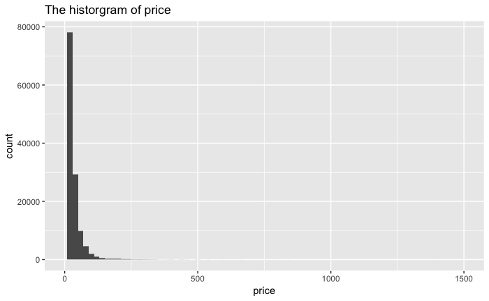

```r
require(ggplot2)
ggplot(winemag, aes(x=price)) + xlim(c(0,1500)) + geom_histogram(binwidth=20) + ggtitle("The historgram of price")
```

2. Plot histogram of points. (10 points)

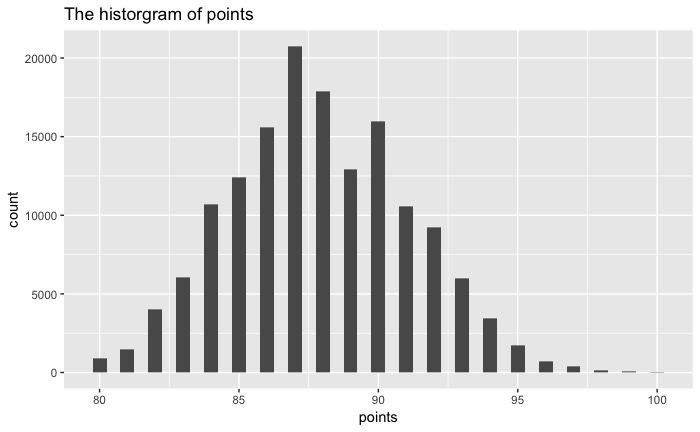

```r
ggplot(winemag, aes(x=points)) + geom_histogram(binwidth=.5) + ggtitle("The historgram of points")
```

3. Create a dataframe with country, variety, average value of points and average value of price.

```r
require(dplyr)
df_3 <- winemag %>% group_by(country,variety) %>% summarize(avgPoints = mean(points,na.rm=TRUE),avgPrice = mean(price,na.rm=TRUE))
head(df_3)
```

| country | variety | avgPoints | avgPrice |
| --- | --- | --- | --- |
|  | Assyrtiko | 90.00000 | 17.00000 |
|  | Pinot Noir | 81.00000 | 15.00000 |
|  | Red Blend | 90.00000 | 30.00000 |
| Albania | Kallmet | 88.00000 | 20.00000 |
| Argentina | Barbera | 85.00000 | 18.00000 |
| Argentina | Bonarda | 86.22517 | 15.02649 |

4. Arrange the above dataframe in descending order of points. Plot heatmap considering first 10 values of the arranged dataframe. The x axis of heat map should have countries, y axis should have variety, and the heat map should be filled with values of average points (10 points)

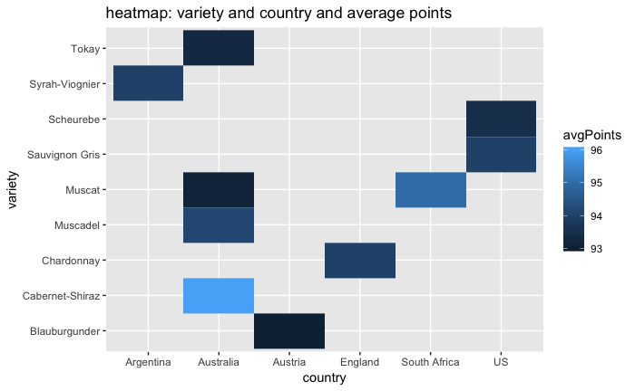

```r
df_4 <- df_3 %>% arrange(desc(avgPoints)) %>% head(10)
ggplot(df_4,aes(x=country,y=variety))+geom_tile(aes(fill=avgPoints)) + ggtitle("heatmap: variety and country and average points")
```

5. Is there a relationship between average price and average points. Compute the Pearson correlation coefficient. Plot a scatter plot with average points on x axis and average price on y axis. Fit a linear model and compute the values of slope and intercept. (20 points)

```r
peaCorr <- cor.test(x=df_3$avgPoints, y=df_3$avgPrice, method = 'pearson')
peaCorr
```

```
    Pearson's product-moment correlation

data:  df_3$avgPoints and df_3$avgPrice
t = 21.35, df = 1441, p-value < 2.2e-16
alternative hypothesis: true correlation is not equal to 0
95 percent confidence interval:
 0.4499936 0.5284495
sample estimates:
      cor
0.4902139
```

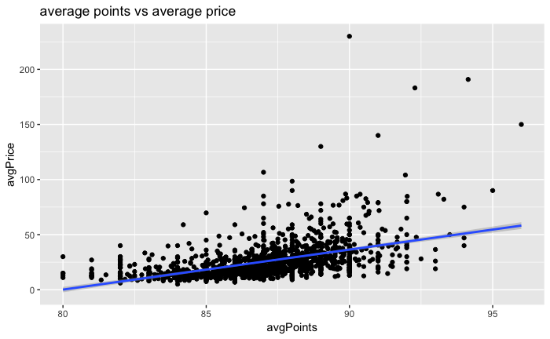

```r
ggplot(df_3, aes(x=avgPoints, y=avgPrice)) + geom_point() + geom_smooth(method=lm) + ggtitle("average points vs average price")
```

```r
fit = lm(formula = df_3$avgPrice ~ df_3$avgPoints)
fit
```

```
Call:
lm(formula = df_3$avgPrice ~ df_3$avgPoints)

Coefficients:
   (Intercept)  df_3$avgPoints
      -290.380           3.631
```

6. Does a winery offering more variety of wines attract more points on average? Is there a trend between variety and average points? (10 points)

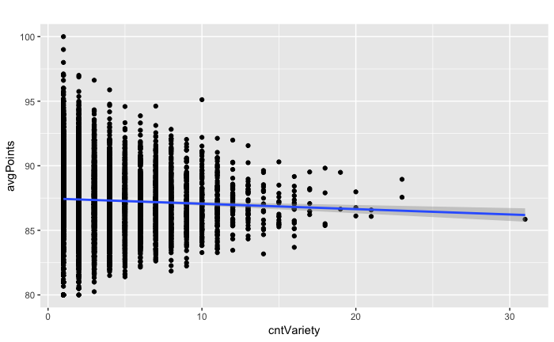

```r
df_6 <- winemag %>% group_by(winery) %>% summarize(cntVariety = n_distinct(variety), avgPoints = mean(points,na.rm=TRUE))
ggplot(df_6, aes(x=cntVariety, y=avgPoints)) + geom_point() + geom_smooth(method=lm) + ggtitle("")
```

```r
cor(as.numeric(df_6$cntVariety),as.numeric(df_6$avgPoints))
```

```
[1] -0.03686138
```

Jugding by the graph and correlation, there is no relationship between the variety and average points.

Problem 2.

```r
require(igraph)
edgelist <- read.csv("~/Downloads/edgelist.csv", stringsAsFactors=FALSE)
egraph <- edgelist[c(2,3)] %>% graph_from_data_frame()
as.matrix(get.adjacency(egraph))
```

```
    s01 s02 s03 s04 s05 s06 s07 s08 s09 s10 s12 s13 s14 s15 s16 s17 s11
s01   0   1   1   1   0   0   0   0   0   0   0   0   0   1   0   0   0
s02   1   0   1   0   0   0   0   0   1   1   0   0   0   0   0   0   0
s03   1   0   0   1   1   0   0   1   0   1   1   0   0   0   0   0   1
s04   0   0   1   0   0   1   0   0   0   0   1   0   0   0   0   1   1
s05   1   1   0   0   0   0   0   0   1   0   0   0   0   1   0   0   0
s06   0   0   0   0   0   1   0   0   0   0   0   0   0   0   1   1   0
s07   0   0   1   0   0   0   0   1   0   1   0   0   1   0   0   0   0
s08   0   0   1   0   0   0   1   0   1   0   0   0   0   0   0   0   0
s09   0   0   0   0   0   0   0   0   0   1   0   0   0   0   0   0   0
s10   0   0   1   0   0   0   0   0   0   0   0   0   0   0   0   0   0
s12   0   0   0   0   0   1   0   0   0   0   0   1   1   0   0   0   0
s13   0   0   0   0   0   0   0   0   0   0   1   0   0   0   0   1   0
s14   0   0   0   0   0   0   0   0   0   0   0   1   0   0   0   0   1
s15   1   0   0   1   0   1   0   0   0   0   0   0   0   0   0   0   0
s16   0   0   0   0   0   1   0   0   0   0   0   0   0   0   0   1   0
s17   0   0   0   1   0   0   0   0   0   0   0   0   0   0   0   0   0
s11   0   0   0   0   0   0   0   0   0   0   0   0   0   0   0   0   0
```

2. Use the adjacency matrix created above and convert it to a network object using igraph package. Plot the network showing all the node labels. (10 points)

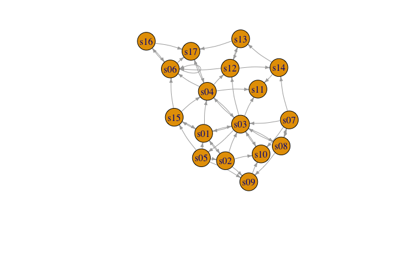

```r
V(egraph)$size <- 25
simplify(egraph) %>% plot(edge.arrow.size=.4, edge.curved=.1)
```

3. Add a node (vertex) attribute and name it as type. Assign value A to nodes S01 to s08, value B to nodes S09 to s14, and value C to nodes S15 to s17. Plot the network showing all node labels and color node by type attribute. (10 points)

```r
V(egraph)$type[V(egraph)$name %in% c("s01","s02","s03","s04","s05","s06","s07","s08")] <- "A"
V(egraph)$type[V(egraph)$name %in% c("s09","s10","s11","s12","s13","s14")] <- "B"
V(egraph)$type[V(egraph)$name %in% c("s15","s16","s17")] <- "C"
col <- c("gray50", "tomato", "gold")
V(egraph)$color <- col[factor(V(egraph)$type) %>% as.numeric()]
simplify(egraph) %>% plot(edge.arrow.size=.4, edge.curved=.1)
```

[output not shown]

4. Plot the network showing all nodes such that the node sizes are varied according their respective degrees. (10 points)

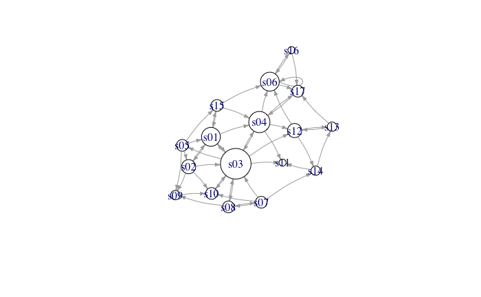

```r
deg <- degree(egraph,mode="all")
V(egraph)$size <- deg*3
V(egraph)$color <- "white"
simplify(egraph) %>% plot(edge.arrow.size=.4, edge.curved=.1)
```